# The Commuter’s Dilemma: Stress, Delays, and Productivity

William Batkin

## Introduction: The Daily Transit Log

For this project, I wanted to explore the reality of my daily commute. I reused my observational logging form from Project 2 to track my transit experiences, but expanded the scope to measure not just logistical delays, but my personal stress levels (on a scale of 1 to 5) and how I chose to spend my time during the journey. This data was collected over 20 weekday trips from myself, my sister and friends providing a snapshot of how environmental factors and bus time reliability impact overall well being and productivity.

## The Weekly Grind: Tracking Stress

The first question I wanted to answer was whether certain days of the week are inherently more stressful than others. Does the anticipation of Monday or the exhaustion of Friday dictate the commuter experience?

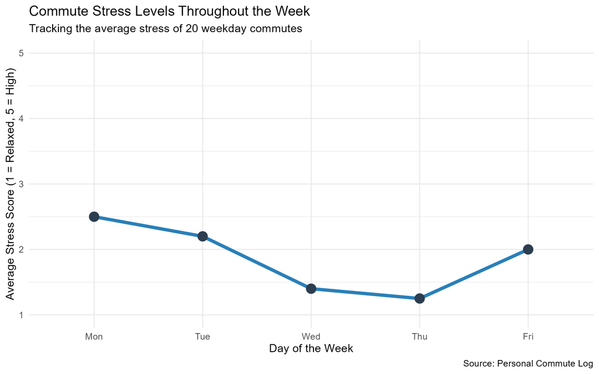

A line graph showing the average stress levels of commutes from Monday to Friday. The y-axis ranges from 1 (Relaxed) to 5 (High Stress). The data points are connected by a thick blue line.